[figure not shown]

# CP6. [실습] 데이터 전처리와 시각화: 서울인구

- 본 실습은 간단한 데이터 시각화 방법을 직접 체험하기 위한 것입니다.
- 차트를 화려하게 꾸미는데 목적을 두지 말고 전처리 부분에 중점을 두는 것이 좋습니다.
- 우선 다음과 같은 과정으로 데이터 시각화를 수행함으로 알고 진행하기 바랍니다.

[figure not shown]

```python
# 라이브러리 불러오기
import numpy as np
import pandas as pd
import matplotlib.pyplot as plt
import matplotlib.image as mpimg

%matplotlib inline
%config InlineBackend.figure_format = 'retina'
```

## 1. 데이터 불러오기

```python
# 서울인구(전체)
file_path = 'https://raw.githubusercontent.com/Jangrae/csv/master/seoul_pop01.csv'
seoul01 = pd.read_csv(file_path)
```

```python
# 서울인구(내국인)
file_path = 'https://raw.githubusercontent.com/Jangrae/csv/master/seoul_pop02.csv'
seoul02 = pd.read_csv(file_path)
```

```python
# 서울인구(외국인)
file_path = 'https://raw.githubusercontent.com/Jangrae/csv/master/seoul_pop03.csv'
seoul03 = pd.read_csv(file_path)
```

## 2. 데이터 확인

- 데이터를 알아야 데이터를 분석할 수 있습니다.
- 우선 분석할 데이터가 어떤 형태의 데이터인지 확인합니다.

**1) 상위/하위 데이터 확인**

- **head()**, **tail()** 메소드로 상/하위 데이터를 확인합니다.

**seoul01: 서울시 남녀 인구(외국인+내국인)**

```python
# 상위 5개 행 확인
seoul01.head()
```

|  | year | male | female |
| --- | --- | --- | --- |
| 0 | 1995 | 533 | 527 |
| 1 | 1996 | 526 | 521 |
| 2 | 1997 | 521 | 517 |
| 3 | 1998 | 517 | 515 |
| 4 | 1999 | 517 | 515 |

```python
# 하위 5개 행 확인
seoul01.tail()
```

|  | year | male | female |
| --- | --- | --- | --- |
| 19 | 2014 | 511 | 526 |
| 20 | 2015 | 506 | 523 |
| 21 | 2016 | 501 | 520 |
| 22 | 2017 | 496 | 517 |
| 23 | 2018 | 491 | 514 |

**seoul02: 서울시 남녀 내국인 인구**

```python
# 상위 5개 행 확인
seoul02.head()
```

|  | year | male | female |
| --- | --- | --- | --- |
| 0 | 2000 | 517 | 514 |
| 1 | 2001 | 514 | 512 |
| 2 | 2002 | 511 | 510 |
| 3 | 2003 | 508 | 509 |
| 4 | 2004 | 507 | 510 |

```python
# 하위 5개 행 확인
seoul02.tail()
```

|  | year | male | female |
| --- | --- | --- | --- |
| 14 | 2014 | 498 | 512 |
| 15 | 2015 | 493 | 509 |
| 16 | 2016 | 488 | 505 |
| 17 | 2017 | 483 | 503 |
| 18 | 2018 | 477 | 499 |

**seoul03: 서울시 남녀 외국인 인구**

```python
# 상위 5개 행 확인
seoul03.head()
```

|  | year | male | female |
| --- | --- | --- | --- |
| 0 | 2000 | 3 | 3 |
| 1 | 2001 | 3 | 3 |
| 2 | 2002 | 4 | 4 |
| 3 | 2003 | 5 | 5 |
| 4 | 2004 | 5 | 6 |

```python
# 하위 5개 행 확인
seoul03.tail()
```

|  | year | male | female |
| --- | --- | --- | --- |
| 14 | 2014 | 13 | 14 |
| 15 | 2015 | 13 | 14 |
| 16 | 2016 | 13 | 14 |
| 17 | 2017 | 13 | 14 |
| 18 | 2018 | 14 | 15 |

**2) 열 데이터 개수, NaN 값 여부 확인**

- **info()** 메소드로 각 열의 값 개수, **NaN**값 포함 여부를 확인합니다.
- NaN값이 포함되어 있으면 결측치에 대한 해결(제거 또는 변경)이 필요합니다.

```python
# 열 정보, NaN 값 포함 여부 확인
seoul01.info()
```

```
<class 'pandas.core.frame.DataFrame'>
RangeIndex: 24 entries, 0 to 23
Data columns (total 3 columns):
 #   Column  Non-Null Count  Dtype
---  ------  --------------  -----
 0   year    24 non-null     int64
 1   male    24 non-null     int64
 2   female  24 non-null     int64
dtypes: int64(3)
memory usage: 704.0 bytes
```

**3) 기초 통계 정보 확인**

- **describe()** 메소드를 사용해 기초 통계 정보를 확인합니다.

**seoul01**

```python
# 기초 통계 정보 확인
seoul01.describe()
```

|  | year | male | female |
| --- | --- | --- | --- |
| count | 24.000000 | 24.000000 | 24.000000 |
| mean | 2006.500000 | 514.625000 | 521.291667 |
| std | 7.071068 | 9.116695 | 6.096893 |
| min | 1995.000000 | 491.000000 | 514.000000 |
| 25% | 2000.750000 | 512.750000 | 516.000000 |
| 50% | 2006.500000 | 516.500000 | 520.500000 |
| 75% | 2012.250000 | 518.500000 | 526.250000 |
| max | 2018.000000 | 533.000000 | 534.000000 |

**seoul02**

```python
# 기초 통계 정보 확인
seoul02.describe()
```

|  | year | male | female |
| --- | --- | --- | --- |
| count | 19.000000 | 19.000000 | 19.000000 |
| mean | 2009.000000 | 502.578947 | 511.263158 |
| std | 5.627314 | 10.473861 | 4.998245 |
| min | 2000.000000 | 477.000000 | 499.000000 |
| 25% | 2004.500000 | 499.500000 | 509.500000 |
| 50% | 2009.000000 | 506.000000 | 512.000000 |
| 75% | 2013.500000 | 507.500000 | 514.000000 |
| max | 2018.000000 | 517.000000 | 520.000000 |

**seoul03**

```python
# 기초 통계 정보 확인
seoul03.describe()
```

|  | year | male | female |
| --- | --- | --- | --- |
| count | 19.000000 | 19.000000 | 19.000000 |
| mean | 2009.000000 | 9.736842 | 10.526316 |
| std | 5.627314 | 4.011679 | 4.350842 |
| min | 2000.000000 | 3.000000 | 3.000000 |
| 25% | 2004.500000 | 5.500000 | 6.500000 |
| 50% | 2009.000000 | 12.000000 | 13.000000 |
| 75% | 2013.500000 | 13.000000 | 14.000000 |
| max | 2018.000000 | 14.000000 | 15.000000 |

**4) 질문**

- seoul01, 02, 03 데이터가 분석하기에 적절한 형태인가요?
- seoul01, 02, 03 데이터에 대해 어떤 분석이 의미가 있을까요?
- 분석에 걸림돌이 될 만한 것은 무엇일까요?
- 분석을 위해 우선 어떤 처리를 해야 할까요?

## 3. 데이터 전처리

- NaN 값이 포함된 열이 있으면 제거하거나 다른 값으로 채워야 합니다.
- 중복된 데이터는 정확한 분석을 방해하므로 제거해야 합니다.
- 기타 데이터에 방해가 되는 요소를 전처리 과정에서 제거합니다.

## 4. 데이터 추가

- 분석에 필요한 데이터가 항상 제공되는 것은 아닙니다.
- 분석을 위해 필요한 데이터를 직접 만들어야 하는 경우가 많습니다.
- 기존 데이터를 사용해 새로운 데이터를 만들 수 있으면 좋습니다.

**1) 데이터 조인**

- 데이터가 세 개로 나뉘어 있어 분석이 번거로울 것입니다.
- 세 개의 데이터를 year를 기준으로 조인해서 하나로 만듭니다.
- 우선 outer join을 한 결과를 살피기로 합니다.
- 조인된 결과 데이터프레임 이름은 seoul로 합니다.

**seoul01, seoul02 조인**

- 우선 **seoul01**, **seoul02**를 조인해서 **seoul** 데이터프레임을 만듭니다.
- **pd.merge()** 함수를 사용해 조인합니다.
- **on='year'**를 지정해 year 열을 기준으로 조인합니다.
- **how='outer'**를 지정해 outer 조인을 합니다.
- 열 이름은 나중에 한 번에 바꾸도록 합니다.

```python
# seoul01, seoul02 outer join
seoul = pd.merge(seoul01, seoul02, on='year', how='outer')

# 확인
seoul.head(10)
```

|  | year | male_x | female_x | male_y | female_y |
| --- | --- | --- | --- | --- | --- |
| 0 | 1995 | 533 | 527 | NaN | NaN |
| 1 | 1996 | 526 | 521 | NaN | NaN |
| 2 | 1997 | 521 | 517 | NaN | NaN |
| 3 | 1998 | 517 | 515 | NaN | NaN |
| 4 | 1999 | 517 | 515 | NaN | NaN |
| 5 | 2000 | 520 | 518 | 517.0 | 514.0 |
| 6 | 2001 | 518 | 516 | 514.0 | 512.0 |
| 7 | 2002 | 514 | 514 | 511.0 | 510.0 |
| 8 | 2003 | 513 | 514 | 508.0 | 509.0 |
| 9 | 2004 | 513 | 516 | 507.0 | 510.0 |

**seoul, seoul03 조인**

```python
# seoul, seoul02 outer join
seoul = pd.merge(seoul, seoul03, on='year', how='outer')

# 확인
seoul.head(10)
```

|  | year | male_x | female_x | male_y | female_y | male | female |
| --- | --- | --- | --- | --- | --- | --- | --- |
| 0 | 1995 | 533 | 527 | NaN | NaN | NaN | NaN |
| 1 | 1996 | 526 | 521 | NaN | NaN | NaN | NaN |
| 2 | 1997 | 521 | 517 | NaN | NaN | NaN | NaN |
| 3 | 1998 | 517 | 515 | NaN | NaN | NaN | NaN |
| 4 | 1999 | 517 | 515 | NaN | NaN | NaN | NaN |
| 5 | 2000 | 520 | 518 | 517.0 | 514.0 | 3.0 | 3.0 |
| 6 | 2001 | 518 | 516 | 514.0 | 512.0 | 3.0 | 3.0 |
| 7 | 2002 | 514 | 514 | 511.0 | 510.0 | 4.0 | 4.0 |
| 8 | 2003 | 513 | 514 | 508.0 | 509.0 | 5.0 | 5.0 |
| 9 | 2004 | 513 | 516 | 507.0 | 510.0 | 5.0 | 6.0 |

**2) 열 이름 변경**

- 열 이름의 _x, _y로는 의미를 알 수 없으니, 열 이름을 적절히 수정합니다.
- male_x --> male, female_x --> female
- male_y --> k_male, female_y --> k_female
- male --> f_male, female --> f_female

```python
# 열 이름 변경
seoul.rename(columns={'male_x': 'male',   'female_x': 'female',
                      'male_y': 'k_male', 'female_y': 'k_female',
                      'male'  : 'f_male',   'female': 'f_female'}, inplace=True)

# 확인
seoul.head(10)
```

|  | year | male | female | k_male | k_female | f_male | f_female |
| --- | --- | --- | --- | --- | --- | --- | --- |
| 0 | 1995 | 533 | 527 | NaN | NaN | NaN | NaN |
| 1 | 1996 | 526 | 521 | NaN | NaN | NaN | NaN |
| 2 | 1997 | 521 | 517 | NaN | NaN | NaN | NaN |
| 3 | 1998 | 517 | 515 | NaN | NaN | NaN | NaN |
| 4 | 1999 | 517 | 515 | NaN | NaN | NaN | NaN |
| 5 | 2000 | 520 | 518 | 517.0 | 514.0 | 3.0 | 3.0 |
| 6 | 2001 | 518 | 516 | 514.0 | 512.0 | 3.0 | 3.0 |
| 7 | 2002 | 514 | 514 | 511.0 | 510.0 | 4.0 | 4.0 |
| 8 | 2003 | 513 | 514 | 508.0 | 509.0 | 5.0 | 5.0 |
| 9 | 2004 | 513 | 516 | 507.0 | 510.0 | 5.0 | 6.0 |

**3) NaN 값 제거**

- 전체 인구는 1995~1999년 데이터가 있지만, 내국인, 외국인 분류의 경우는 없습니다.
- 1995~1999년 데이터는 버리기로 합시다.
- 앞의 과정에서 inner join을 했으면 1995~1999년 데이터는 자동으로 삭제되었을 겁니다.

```python
# NaN이 있는 행 제거
seoul.dropna(inplace=True)

# NaN값 존재 여부 확인
seoul.info()
```

```
<class 'pandas.core.frame.DataFrame'>
Int64Index: 19 entries, 5 to 23
Data columns (total 7 columns):
 #   Column    Non-Null Count  Dtype
---  ------    --------------  -----
 0   year      19 non-null     int64
 1   male      19 non-null     int64
 2   female    19 non-null     int64
 3   k_male    19 non-null     float64
 4   k_female  19 non-null     float64
 5   f_male    19 non-null     float64
 6   f_female  19 non-null     float64
dtypes: float64(4), int64(3)
memory usage: 1.2 KB
```

**4) 데이터 형식 변경**

- k_male, k_female, f_male, f_female 열도 정수 형식으로 바꿉니다.

```python
# 데이터 형식 바꾸기
pop_list = ['k_male', 'k_female', 'f_male', 'f_female']
for pop in pop_list:
    seoul[pop] = seoul[pop].astype(int)

# 확인
seoul.info()
```

```
<class 'pandas.core.frame.DataFrame'>
Int64Index: 19 entries, 5 to 23
Data columns (total 7 columns):
 #   Column    Non-Null Count  Dtype
---  ------    --------------  -----
 0   year      19 non-null     int64
 1   male      19 non-null     int64
 2   female    19 non-null     int64
 3   k_male    19 non-null     int32
 4   k_female  19 non-null     int32
 5   f_male    19 non-null     int32
 6   f_female  19 non-null     int32
dtypes: int32(4), int64(3)
memory usage: 912.0 bytes
```

```python
# 최종 결과 확인
seoul.head(10)
```

|  | year | male | female | k_male | k_female | f_male | f_female |
| --- | --- | --- | --- | --- | --- | --- | --- |
| 5 | 2000 | 520 | 518 | 517 | 514 | 3 | 3 |
| 6 | 2001 | 518 | 516 | 514 | 512 | 3 | 3 |
| 7 | 2002 | 514 | 514 | 511 | 510 | 4 | 4 |
| 8 | 2003 | 513 | 514 | 508 | 509 | 5 | 5 |
| 9 | 2004 | 513 | 516 | 507 | 510 | 5 | 6 |
| 10 | 2005 | 512 | 517 | 506 | 510 | 6 | 7 |
| 11 | 2006 | 515 | 521 | 506 | 512 | 8 | 9 |
| 12 | 2007 | 517 | 525 | 506 | 513 | 11 | 12 |
| 13 | 2008 | 518 | 527 | 506 | 514 | 12 | 13 |
| 14 | 2009 | 518 | 528 | 506 | 515 | 12 | 13 |

## 5. [옵션] 데이터 시각화

- 이제 전처리가 진행된 데이터를 시각화해서 분석합니다.
- 본 실습에서는 간단한 Line Graph를 표시해 보는 것을 목표로 합니다.

**1) 서울시 전체 인구 증감**

- 서울시 전체 인구가 어떻게 변하는지 확인해 봅니다.

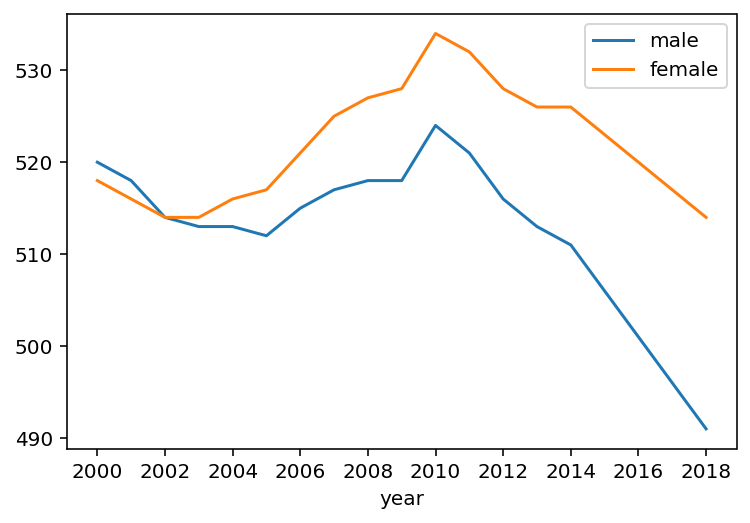

```python
# 서울 전체 인구수 변화
seoul.plot(kind='line', x='year', y=['male', 'female'])
plt.xticks(range(2000, 2019, 2))
plt.show()
```

**2) 서울 내국인 인구 증감**

- 서울시 내국인 인구가 어떻게 변하는지 확인해 봅니다.

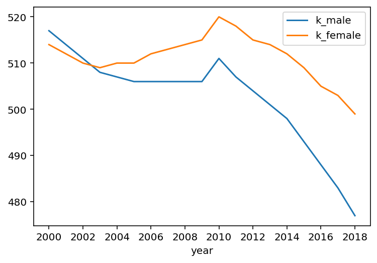

```python
# 서울 내국인 인구수 변화
seoul.plot(kind='line', x='year', y=['k_male', 'k_female'])
plt.xticks(range(2000, 2019, 2))
plt.show()
```

**3) 서울 외국인 인구 증감**

- 서울시 외국인 인구가 어떻게 변하는지 확인해 봅니다.

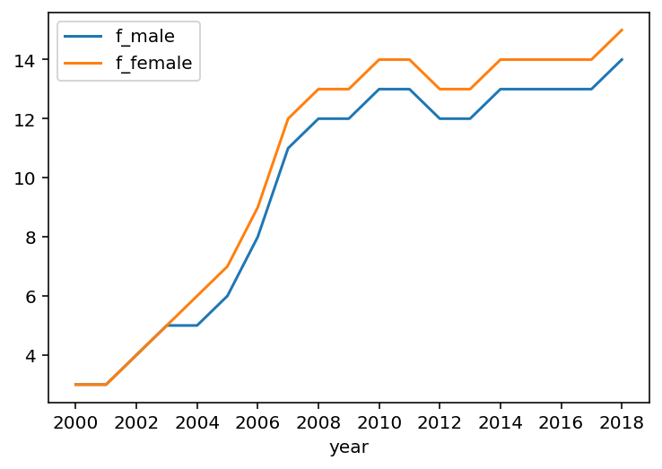

```python
# 서울 외국인 인구수 변화
seoul.plot(kind='line', x='year', y=['f_male', 'f_female'])
plt.xticks(range(2000, 2019, 2))
plt.show()
```

## 6. 의미 찾기

- 데이터 분석을 제대로 하려면 제대로된 데이터가 있어야 합니다.
- 다양한 전처리 방법을 사용해 분석이 용이한 형태로 데이터를 변경해야 합니다.
- 기존 데이터를 활용해 새로운 데이터를 만들 수 있어야 합니다.
- 필요한 데이터가 서로 다른 파일로 나뉘어 있을 때 모두 읽어와 조인해야 합니다.

## 수고하셨습니다.

[figure not shown]